# Potential Disease Outbreak Advisory Report

A review of recent headlines (early 2016) indicates that there are clusters of disease reports for Zika (US, World) and for Mad Cow Disease (Europe).

- Zika Clusters
- Mad Cow Clusters

This data is based on headlines collected over the the first few months of 2016. Additional follow-up may be necessary to determine the exact number and location of cases: headlines may be reporting the same data, may be speculative, or may not correctly indicate the location.

## Please use the links above to navigate to the graphics at the end of this report.

```python
import numpy as np
import pandas as pd               # 0.25.0

import matplotlib as mpl
import matplotlib.pyplot as plt
from mpl_toolkits.basemap import Basemap
%matplotlib inline
```

```python
df_us_zika = pd.read_csv(r'../data-files/s4_us_zika.csv')
df_w_zika = pd.read_csv(r'../data-files/s4_world_zika.csv')
df_w_madcow = pd.read_csv(r'../data-files/s4_world_madcow.csv')
```

```python
# https://stackoverflow.com/questions/17411940/matplotlib-scatter-plot-legend
# Handy way to build the legend
def get_legend_markers(D_label_color, marker="o", marker_kws={"linestyle":""}):
    """
    Usage: plt.legend(*legend_vars(D_taxon_color),
                      loc="lower center",
                      bbox_to_anchor=(0.5,-0.15),
                      fancybox=True, shadow=True,
                      prop={'size':15})

    Input: Dictionary object of {label:color}
    Output: Tuple of markers and labels
    """
    # Any marker you want to have in the legend must be put on the plot; this makes sure
    # that it's on there.
    markers = [plt.Line2D([0,0],[0,0],color=color, marker=marker,\
                          **marker_kws) for color in D_label_color.values()]
    return (markers, D_label_color.keys())
```

```python
def draw_cluster_map(df_in:pd.DataFrame,cluster_column:str,title:str,\
                    show_states=False, show_rivers=False,set_res='c',spot_size=50,\
                    ax=None,show_legend=True):
    '''Takes in a dataframe that has the columns latitude, longitude, DBSCAN_cluster and
       draws the clusters on a map
       INPUTS:
           dataframe          pandas dataframe
           cluster_column     Name of the column containing the cluster integer
           title              Title to print on the map
           show_states        Draw the outlines of US states
           show_rivers        Draw rivers (useful for waterborne diseases)
           set_res            Set the resolution to c=crude, l=low, i=intermediate, h=high, f=full
    '''
    # setting up the zoom -- here's the whole world
    m_llcrnrlon = -180
    m_llcrnrlat = -90
    m_urcrnrlon = 180
    m_urcrnrlat = 90

    # try calculating zoom
    if (1):
        border = 5.0
        m_llcrnrlat = df_in['latitude'].min() - border
        m_urcrnrlat = df_in['latitude'].max() + border
        m_llcrnrlon = df_in['longitude'].min() - border
        m_urcrnrlon = df_in['longitude'].max() + border

    # started with 'cyl'
    # try 'mill' for miller and add resolution

    if (ax == None):
        ax = plt.gca()

    map_plotter = Basemap(projection='cyl',\
                                     llcrnrlon = m_llcrnrlon,\
                                     llcrnrlat = m_llcrnrlat,\
                                     urcrnrlon = m_urcrnrlon,\
                                     urcrnrlat = m_urcrnrlat,\
                                     ax=ax,\
                                     resolution=set_res)

    cc1 = df_in[cluster_column].unique()
    cc2 = np.sort(cc1, axis=-1, kind='quicksort', order=None)
    cc2
    # Working out colors and legend match-up
    color_order =['blue', 'cyan', 'magenta','lime', \
                  'pink', 'coral', 'purple', 'teal', 'brown', 'black',\
                  'orange', 'red', 'lightblue', 'gold',\
                  'lavender', 'turquoise', 'darkgreen', 'tan', 'salmon', \
                  'yellow', 'plum', 'olive', 'burlywood', 'darkorange',\
                  'peru', 'tomato', 'saddlebrown', 'cadetblue', 'thistle',\
                  'forestgreen', 'darkkhaki', 'green', 'royalblue']


    D_label_color = {}

    #plt.figure(figsize=(20, 20))

    map_plotter.drawcoastlines()
    map_plotter.drawcountries()
    map_plotter.shadedrelief()
    if (show_states):
        map_plotter.drawstates()
    if (show_rivers):
        map_plotter.drawrivers()


#    for c in range(-1,len(cc2)-1):
    for c in cc2:
        mini_df = df_in[df_in[cluster_column]==c]
        lat_list = mini_df['latitude']
        lon_list = mini_df['longitude']
        if (c == -1):
            map_plotter.scatter(lon_list,lat_list,latlon=True, c='red', marker = 'x',s=spot_size)
            D_label_color["Isolate"] = 'red'
        else:
            map_plotter.scatter(lon_list,lat_list,latlon=True, c=color_order[c],s=spot_size)
            str_cluster = "Cluster " + str(c)
            D_label_color[str_cluster]=color_order[c]

    #ax = plt.gca()
    #plt.title(title)
    ax.set_title(title)

    if (show_legend):
        bbox_1 = (0, 0, 1.09, 1)   # puts legend on the right, may overlap the map
        bbox_2 = (0, 0, .096, .32) # puts it in lower left, but may cover data
        bbox_3 = (0, 0, 1.1, 1)
        ax.legend(*get_legend_markers(D_label_color),bbox_to_anchor=bbox_3)

    return map_plotter
```

# ZIKA clusters

From https://www.cdc.gov/zika/about/index.html:

"Zika is spread mostly by the bite of an infected Aedes species mosquito (Ae. aegypti and Ae. albopictus). These mosquitoes bite during the day and night. Zika can be passed from a pregnant woman to her fetus. Infection during pregnancy can cause certain birth defects. There is no vaccine or medicine for Zika.""

Return to top of report

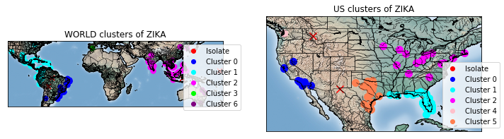

```python
fig, axes = plt.subplots(1,2,figsize=(12,5))
m = draw_cluster_map(df_w_zika,'DBSCAN_cluster_e','WORLD clusters of ZIKA',True,True,'l',ax=axes[0])
m = draw_cluster_map(df_us_zika,'DBSCAN_cluster_gc','US clusters of ZIKA',True,True,'l',100,ax=axes[1])
```

Above: Snapshots of the cluster maps. See detailed maps below.

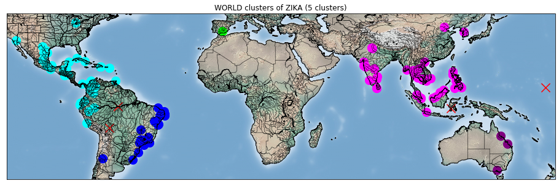

```python
fig, ax2 = plt.subplots(figsize=(16,12))
m = draw_cluster_map(df_w_zika,'DBSCAN_cluster_e','WORLD clusters of ZIKA (5 clusters)',
                     True,True,'l',200,ax=ax2,show_legend=False)
plt.savefig('../data-files/s5_world_zika.png', dpi=300)
```

There are 5 large world clusters:

```
* North America - Central America - South America (west coast)
* South America (east coast)
* Southern Europe (Spain)
* South Asia
* Oceania (Australia east coast)
```

Isolated reports are designated with a red X.

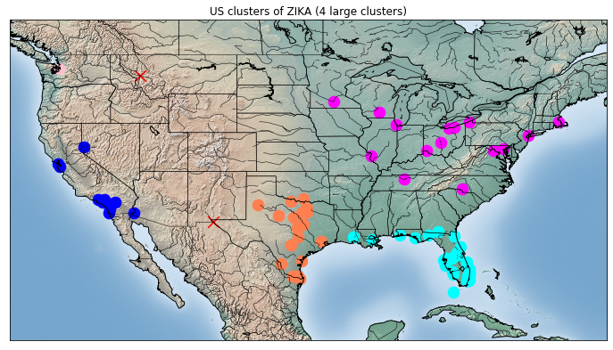

```python
fig, ax1 = plt.subplots(figsize=(12,10))
m = draw_cluster_map(df_us_zika,'DBSCAN_cluster_gc','US clusters of ZIKA (4 large clusters)',
                     True,True,'l',160,ax=ax1,show_legend=False)
plt.savefig('../data-files/s5_US_zika.png', dpi=300)
```

There are 4 large US clusters:

```
* West Coast (California) - which may be contiguous with cases on the west coast of Mexico
* Gulf Coast (Texas) - which may be contiguous with cases on the east coast of Mexico
* Gulf States (Louisiana, Mississippi, Alabama, Florida, Georgia)
* Upper Midwest to Atlantic
```

See the maps below to compare these reports with the latest information on the range of the mosquitos that are known to carry Zika.

Isolated reports are designated with a red X.

From https://www.cdc.gov/zika/vector/range.html: The habitat of the Ae. aegypti and Ae. albopicus mosquitos includes coastal and temperate regions of the US. The following 2017 maps of the suspected habitat align with the US cases, although the cases imply that the habitat may be expanding north and inland following the paths of rivers.

[figure not shown]

# MAD COW clusters

From https://www.cdc.gov/prions/bse/: "Bovine Spongiform Encephalopathy (BSE) is a progressive neurological disorder of cattle...that peaked in January, 1993."

While this is a disease in cattle and not in humans, there has been

"strong...evidence...for a causal association between a new human prion disease called variant Creutzfeldt-Jakob disease (vCJD) that was first reported from the United Kingdom in 1996 and the BSE outbreak in cattle."

Some research indicates that outbreaks of BSE (mad cow) can be followed about 10 years later by outbreaks of vCJD.

Return to top of report

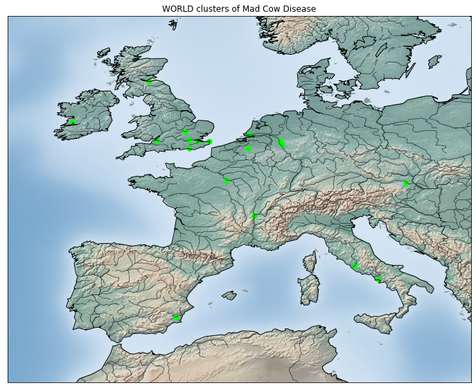

```python
fig, ax3 = plt.subplots(figsize=(12,10))
m = draw_cluster_map(df_w_madcow,'DBSCAN_cluster_e','WORLD clusters of Mad Cow Disease',
                     True,True,'l',50,ax = ax3,show_legend=False)
plt.savefig('../data-files/s5_Europe_MadCow.png', dpi=300)
```

At this time, Mad Cow Disease reports are clustered only in Western Europe.

Return to top of report